# Quizz 8: Poisson

Back to Index

## Cookies

**For Questions 1-8, consider the chocolate chip cookie example from the lesson.**

As in the lesson, we use a Poisson likelihood to model the number of chips per cookie, and a conjugate gamma prior on $\lambda$, the expected number of chips per cookie. Suppose your prior expectation for $\lambda$ is 8.

### Question 1

The conjugate prior with mean 8 and effective sample size of 2 is $\text{Gamma}(a,2)$. Find the value of a.

- prior mean $E[\lambda] = \frac{\alpha}{\beta} = 8$
- effective sample size $n_{eff} = \beta = 2$
- $\Rightarrow \alpha = 8 \times 2 = 16$

### Question 2

The conjugate prior with mean 8 and standard deviation 1 is $\text{Gamma(a,8)}$. Find the value of a.

- $E[\lambda] = \frac{\alpha}{\beta} = 8$
- std. dev. $\frac{\sqrt{\alpha}}{\beta} = 1$
- $\Rightarrow \alpha = 64$

### Question 3

Suppose you are not very confident in your prior guess of 8, so you want to use a prior effective sample size of 1/100 cookies. Then the conjugate prior is $\text{Gamma}(a, 0.01)$. Find the value of a. Round your answer to two decimal places.

- prior mean $E[\lambda] = \frac{\alpha}{\beta} = 8$
- effective sample size $n_{eff} = \beta = 0.01$
- $\Rightarrow \alpha = 8 \times 0.01 = 0.08$

**Distributions in Q1, 2, 3**

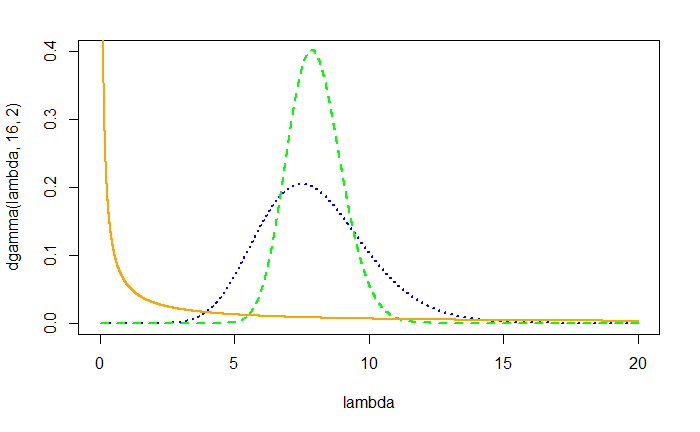

### Question 4

Suppose you decide on the prior $\text{Gamma}(8, 1)$, which has prior mean 8 and effective sample size of one cookie.

We collect data, sampling five cookies and counting the chips in each. We find 9, 12, 10, 15, and 13 chips.

What is the posterior distribution for $\lambda$?

### Question 5

Continuing the previous question, what of the following graphs shows the prior density (dotted line) and posterior density (solid line) of $\lambda$?

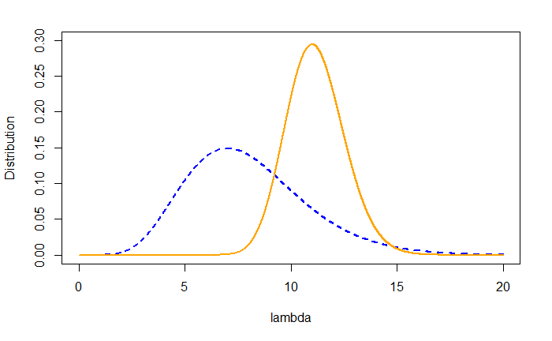

### Question 6

Continuing Question 4, what is the posterior mean for $\lambda$? Round your answer to one decimal place.

- posterior mean $E[\lambda \mid Y] = \frac{\alpha ~+~ \sum Y_i}{\beta ~+~ n} = 67/6 = 11.2$

### Question 7

Continuing Question 4, use R or Excel to find the lower end of a 90% equal-tailed credible interval for $\lambda$. Round your answer to one decimal place.

```r
qgamma(p=0.05, shape=67, rate=6)
```

```
[1] 9.021382
```

### Question 8

Continuing Question 4, suppose that in addition to the five cookies reported, we observe an additional ten cookies with 109 total chips. What is the new posterior distribution for $\lambda$, the expected number of chips per cookie?

Hint: You can either use the posterior from the previous analysis as the prior here, or you can start with the original $\text{Gamma(8,1)}$ prior and update with all fifteen cookies. The result will be the same.

- prior from 4) $\lambda \sim \Gamma(67, 6)$
- posterior $\lambda \mid Y \sim \Gamma(\alpha + \sum Y_i, \beta + n) = \Gamma(67 + 109,~ 6 + 10) = \Gamma(176, 16)$

## Poisson process

**For Questions 9-10, consider the following scenario:**

A retailer notices that a certain type of customer tends to call their customer service hotline more often than other customers, so they begin keeping track. They decide a Poisson process model is appropriate for counting calls, with calling rate $\theta$ calls per customer per day.

The likelihood for $Y$ is then $f(y \mid \theta) = \frac{(nt\theta)^y e^{-nt\theta}}{y!} \propto \theta^y e^{-nt\theta}$.

This model also has a conjugate gamma prior $\theta \sim \text{Gamma}(a, b)$ which has density (PDF) $f(\theta) = \frac{b^a}{\Gamma(a)} \theta^{a-1} e^{-b\theta} \propto \theta^{a-1} e^{-b\theta}$.

### Question 9

Following the same procedure outlined in the lesson, find the posterior distribution for $\theta$.

Likelihood $Y \sim \text{Poisson}(\theta \cdot n \cdot t)$ $\rightarrow$ $f(y \mid \theta) \propto \theta^y e^{n t \theta}$  
Prior $\Gamma(a, b)$ $\rightarrow$ $f(\theta) \propto \theta^{a-1} e^{-b\theta}$  
$\Rightarrow$ Posterior $f(\theta \mid Y) \propto \theta^{a-1} e^{-b\theta} \theta^y e^{-n t\theta} =$ $\theta^{a+y-1} e^{-\theta(b+n t)}$

$~~~$ i.e. $\theta\mid Y \sim \Gamma(a+y,~b+nt)$

### Question 10

On average, the retailer receives 0.01 calls per customer per day. To give this group the benefit of the doubt, they set the prior mean for $\theta$ at 0.01 with standard deviation 0.5. This yields a $\text{Gamma}(\frac{1}{2500}, \frac{1}{25})$ prior for $\theta$.

- Yes, the posterior mean for $\theta$ is twice the average of $0.01$.
- Yes, most of the posterior mass (probability) is concentrated on values of $\theta$ greater than $0.01$. **[x]**
- No, the posterior mean is exactly $0.01$.
- No, most of the posterior mass (probability) is concentrated on values of $\theta$ less than $0.01$.

Back to Index